# W9 Differential Gene Expression Analysis w DESeq2

```r
library(DESeq2)
```

```r
library(dplyr)
```

```r
 install.packages("reshape2")
```

```
Error in install.packages : Updating loaded packages
```

The count matrices for this analysis were downloaded from the NYU HPC and saved in a local folder titled source_files in this same working directory. #Create a DESeqDataSet object

```r
sampleFiles <- paste(c('PDAC253','PDAC282','PDAC286','PDAC316','PDAC266','PDAC273','PDAC306','PDAC318'),'.htseq_count.txt',sep="")
sampleCondition <- c(rep('highSucrose',4),rep('lowSucrose',4))
sampleTable <- data.frame(sampleName = sampleFiles,
                          fileName = sampleFiles,
                          condition = sampleCondition)
```

```r
sampleTable #Visualizing Sample Table
```

| sampleName | fileName | condition |
| --- | --- | --- |
| PDAC253.htseq_count.txt | PDAC253.htseq_count.txt | highSucrose |
| PDAC282.htseq_count.txt | PDAC282.htseq_count.txt | highSucrose |
| PDAC286.htseq_count.txt | PDAC286.htseq_count.txt | highSucrose |
| PDAC316.htseq_count.txt | PDAC316.htseq_count.txt | highSucrose |
| PDAC266.htseq_count.txt | PDAC266.htseq_count.txt | lowSucrose |
| PDAC273.htseq_count.txt | PDAC273.htseq_count.txt | lowSucrose |
| PDAC306.htseq_count.txt | PDAC306.htseq_count.txt | lowSucrose |
| PDAC318.htseq_count.txt | PDAC318.htseq_count.txt | lowSucrose |

```r
dds <- DESeqDataSetFromHTSeqCount(
  sampleTable = sampleTable,
  directory='/Users/danielaquijano/Documents/Github/Next-Generation-Sequence-Analysis/NGS_Course_Projects/Differential Gene Expression Analysis (W9)/source_files',
  design = ~ condition)
```

```r
dds
```

```
class: DESeqDataSet
dim: 28595 8
metadata(1): version
assays(1): counts
rownames(28595): Pdac_HC_000007FG0000100 Pdac_HC_000007FG0000200 ... Pdac_HC_chr9G0155000 Pdac_HC_chr9G0155100
rowData names(0):
colnames(8): PDAC253.htseq_count.txt PDAC282.htseq_count.txt ... PDAC306.htseq_count.txt PDAC318.htseq_count.txt
colData names(1): condition
```

### 1.1

dds is a DESeq dataset, 28595 rows by 8 cols.

Test the null hypothesis that there is no effect of sugar type on gene expression for each gene in the genome annotation. In the DESeq2 framework, we are testing the null hypothesis of a fold-change of zero separately for each gene in the genome between high sucrose and low sucrose fruits.

```r
class(dds)
```

```
[1] "DESeqDataSet"
attr(,"package")
[1] "DESeq2"
```

## Pre-filter low count genes, normalize counts and run DESeq

```r
#removing genes with 10 or fewer reads
keep <- rowSums(counts(dds)) >= 10
dds <- dds[keep,]
```

```r
#run the DESeq wrapper function.

dds <- DESeq(dds)
class(dds) # Determine the type of object
```

```
[1] "DESeqDataSet"
attr(,"package")
[1] "DESeq2"
```

Obtain raw counts and normalized counts from dds DESeq2 object.

```r
rawcounts.matrix <- counts(dds,normalized=F)
normalizedcounts.matrix <- counts(dds,normalized=T)
class(rawcounts.matrix)
```

```
[1] "matrix" "array"
```

```r
head(normalizedcounts.matrix)
```

```
                        PDAC253.htseq_count.txt PDAC282.htseq_count.txt PDAC286.htseq_count.txt PDAC316.htseq_count.txt
Pdac_HC_000007FG0000100              115.667028               128.50165               52.616528              148.959889
Pdac_HC_000007FG0000200               27.919627                36.48812               30.462200               29.791978
Pdac_HC_000007FG0000300              510.530331               391.85070              571.858579              537.039599
Pdac_HC_000007FG0000400              177.489060               319.66768             1870.656028              318.303762
Pdac_HC_000007FG0000500                5.982777                 6.34576                1.384645                3.135998
Pdac_HC_000007FG0000600               17.948332               137.22707              178.619265               94.079930
                        PDAC266.htseq_count.txt PDAC273.htseq_count.txt PDAC306.htseq_count.txt PDAC318.htseq_count.txt
Pdac_HC_000007FG0000100               214.42625                129.7974              111.718011               191.49936
Pdac_HC_000007FG0000200                34.95053                 47.8420               33.007594                46.87745
Pdac_HC_000007FG0000300               433.57555                300.7806              383.395902               437.85532
Pdac_HC_000007FG0000400               431.68634                361.5191             1090.520132               494.70669
Pdac_HC_000007FG0000500                38.72897                  9.5684                6.347614                 7.97914
Pdac_HC_000007FG0000600               437.35399                148.5182              145.995128               206.46025
```

### Q1.1

```r
dds
```

```
class: DESeqDataSet
dim: 20029 8
metadata(1): version
assays(4): counts mu H cooks
rownames(20029): Pdac_HC_000007FG0000100 Pdac_HC_000007FG0000200 ... Pdac_HC_chr9G0154800 Pdac_HC_chr9G0155000
rowData names(22): baseMean baseVar ... deviance maxCooks
colnames(8): PDAC253.htseq_count.txt PDAC282.htseq_count.txt ... PDAC306.htseq_count.txt PDAC318.htseq_count.txt
colData names(2): condition sizeFactor
```

###2.1 As seen above, 28595 -20029=8566 genes were removed after filtering and normalization. 20029 genes were retained.

##Analyze DGE data Cluster samples using hierarchical clustering and Principal Components Analysis (PCA). This can help provide an indication of the distances between sample gene expression profiles and help detect potential batch effects. Recommended that the normalized count matrix should be transformed with “regularized log” (?rlog) or “variance stabilizing” (?varianceStabilizingTransformation) transformation before clustering.

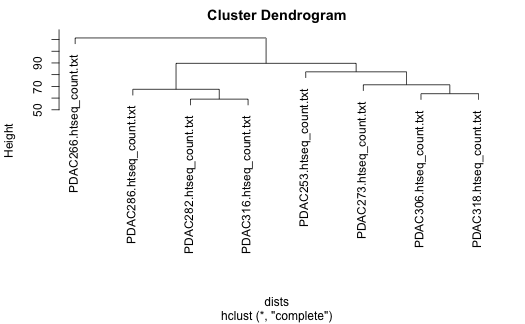

```r
# “rlog” transform the normalized counts and perform hierarchical clustering of samples:
rld <- rlog(dds)
dists <- dist(t(assay(rld)))
plot(hclust(dists))
```

```r
dists
```

```
                        PDAC253.htseq_count.txt PDAC282.htseq_count.txt PDAC286.htseq_count.txt PDAC316.htseq_count.txt
PDAC282.htseq_count.txt                68.78937
PDAC286.htseq_count.txt                83.67614                67.49393
PDAC316.htseq_count.txt                68.98614                59.08885                67.26532
PDAC266.htseq_count.txt               100.40661                93.49482               111.35110                99.63666
PDAC273.htseq_count.txt                74.19303                73.22159                86.61191                73.83981
PDAC306.htseq_count.txt                68.96342                71.67088                89.66504                74.29968
PDAC318.htseq_count.txt                82.42840                74.87346                85.47723                76.48393
                        PDAC266.htseq_count.txt PDAC273.htseq_count.txt PDAC306.htseq_count.txt
PDAC282.htseq_count.txt
PDAC286.htseq_count.txt
PDAC316.htseq_count.txt
PDAC266.htseq_count.txt
PDAC273.htseq_count.txt                85.99880
PDAC306.htseq_count.txt                82.91731                69.18468
PDAC318.htseq_count.txt                81.54638                71.36775                63.75288
```

Cluster samples using the plotPCA function (?plotPCA) and color the points by high or low sucrose content samples

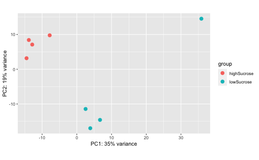

```r
#Make PCA plot
plotPCA(rld)
```

### 3.2b

Yes. The PCA separates all points on the PC1 axis. Note: Although there is one outlier in the far right, when we draw a vertical line we can still cleanly separate high and low sucrose groups despite that one point being vertically far away.

### 3.2c

Potential sources from batch effects: all of the above: sequencer, lane, day, reagents, technicians

### 3.2d

Without any further evidence/statistical analysis I cannot say that there are any batch effects because I do not have information on how the samples were run and without any further analysis, or dimensionality breakdown other than PCA is is hard to identify batch effects.

```r
#Results from the DESeq2 analysis can be extracted from the DESeqDataSet object using the results function.
res <- results(dds, contrast = c('condition','lowSucrose','highSucrose') )
class(res)
```

```
[1] "DESeqResults"
attr(,"package")
[1] "DESeq2"
```

```r
#sort the data ascending on p-value.
#most significant differentially expressed gene at the top.
resOrdered <- res[order(res$pvalue),]
head(resOrdered,10) # View the 10 most significant genes
```

```
log2 fold change (MLE): condition lowSucrose vs highSucrose
Wald test p-value: condition lowSucrose vs highSucrose
DataFrame with 10 rows and 6 columns
                         baseMean log2FoldChange     lfcSE      stat      pvalue        padj
                        <numeric>      <numeric> <numeric> <numeric>   <numeric>   <numeric>
Pdac_HC_chr14G0099800    106.8707       -9.06040  0.981122  -9.23474 2.58920e-20 4.43297e-16
Pdac_HC_chr14G0023100   2915.8578        5.65339  0.630509   8.96639 3.06399e-19 2.62293e-15
Pdac_HC_chr1G0060800      53.1061        5.99993  0.680879   8.81204 1.22891e-18 7.01341e-15
Pdac_HC_000288FG0001200  302.1243        3.88626  0.464925   8.35888 6.33155e-17 2.71006e-13
Pdac_HC_chr14G0022900   2839.3198        9.97881  1.205430   8.27822 1.25031e-16 4.28130e-13
Pdac_HC_chr14G0000300     73.0727       -3.83159  0.466591  -8.21188 2.17751e-16 5.67374e-13
Pdac_HC_chr14G0000200    129.9705       -3.98787  0.486072  -8.20428 2.31973e-16 5.67374e-13
Pdac_HC_000488FG0002000  168.8348       -2.23615  0.279370  -8.00424 1.20204e-15 2.57252e-12
Pdac_HC_000288FG0001100   68.2209        4.49466  0.578376   7.77116 7.77683e-15 1.47941e-11
Pdac_HC_002675FG0000200   28.2773       -8.52724  1.136417  -7.50362 6.20811e-14 1.06289e-10
```

DESeq2 identifies some of the genes displaying these problematic features by conducting “independent filtering”–an automated filtering process that causes p-values and/or adjusted p-values to be set to NA.

### 3.3

Three quality control steps that are automatically conducted by DESeq to drop from consideration genes with suspect, or problematic, p-values How many genes were impacted by the default independent filtering? -If all samples in a row have counts 0, then p value and adjusted p value will be set to NA. -If a row has an outlier count, then p vlaue and adjusted value is set to NA -If a row is filtered for low normalized count only adjusted p value is set to NA In independent filtering the mean of the normalized counts are used as the filter statistic.8566 genes were removed after filtering and normalization.

The genes of interest in this experiment are three invertase genes that are located in a Quantitative Trait Locus (QTL) region approximately 1 Mb in size on chromosome 14 in the date palm genome.Invertase catalyzes the conversion of sucrose to fructose and glucose.

```r
library(pheatmap)
```

```r
#Filter genes from normalized counts using the top 30 most expressed genes
norm_counts_top_30=normalizedcounts.matrix[rownames(head(resOrdered,30)), ]
```

```r
#Here I arrange the annotation columns to generate an annotated and clsutered heatmap using pheatmap
annotation_columns=sampleTable
annotation_columns$fileName <- NULL
```

```r
annotation_columns
```

| sampleName | condition |
| --- | --- |
| PDAC253.htseq_count.txt | highSucrose |
| PDAC282.htseq_count.txt | highSucrose |
| PDAC286.htseq_count.txt | highSucrose |
| PDAC316.htseq_count.txt | highSucrose |
| PDAC266.htseq_count.txt | lowSucrose |
| PDAC273.htseq_count.txt | lowSucrose |
| PDAC306.htseq_count.txt | lowSucrose |
| PDAC318.htseq_count.txt | lowSucrose |

```r
row.names(annotation_columns) <- colnames(norm_counts_top_30)
```

```r
annotation_columns
```

|  | sampleName | condition |
| --- | --- | --- |
| PDAC253.htseq_count.txt | PDAC253.htseq_count.txt | highSucrose |
| PDAC282.htseq_count.txt | PDAC282.htseq_count.txt | highSucrose |
| PDAC286.htseq_count.txt | PDAC286.htseq_count.txt | highSucrose |
| PDAC316.htseq_count.txt | PDAC316.htseq_count.txt | highSucrose |
| PDAC266.htseq_count.txt | PDAC266.htseq_count.txt | lowSucrose |
| PDAC273.htseq_count.txt | PDAC273.htseq_count.txt | lowSucrose |
| PDAC306.htseq_count.txt | PDAC306.htseq_count.txt | lowSucrose |
| PDAC318.htseq_count.txt | PDAC318.htseq_count.txt | lowSucrose |

```r
annotation_columns$sampleName <- NULL
```

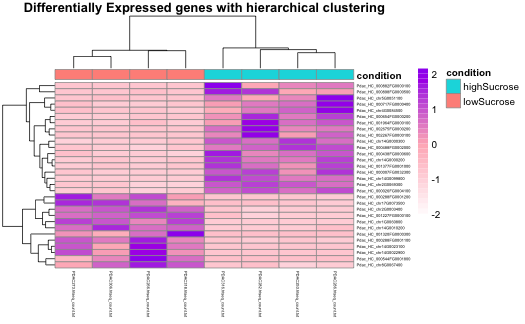

```r
pheatmap(norm_counts_top_30, color=colorRampPalette(c("white", "light pink", "purple"))(30), scale="row", cluster_cols = T, show_rownames = T,fontsize_row = 4, fontsize_col = 4,labels_row = rownames(dists),main='Differentially Expressed genes with hierarchical clustering',annotation_col =annotation_columns )
```

The genes of interest in this experiment are three invertase genes that are located in a Quantitative Trait Locus (QTL) region approximately 1 Mb in size on chromosome 14 in the date palm genome. Invertase catalyzes the conversion of sucrose to fructose and glucose. We would like to know which (if any) of these genes are differentially expressed between sugar types and might control the sugar composition phenotype.  
The gene identifiers of the candidates are:  
Pdac_HC_chr14G0022900 (cell wall invertase enzyme)  
Pdac_HC_chr14G0023100 (cell wall invertase enzyme)  
Pdac_HC_chr14G0028200 (alkaline/neutral invertase enzyme)

```r
#Subset sroted deseq results to find expression of candidate genes
sucrose_genes=resOrdered[ row.names(resOrdered) %in% c('Pdac_HC_chr14G0022900','Pdac_HC_chr14G0023100','Pdac_HC_chr14G0028200'), ]
sucrose_genes
```

```
log2 fold change (MLE): condition lowSucrose vs highSucrose
Wald test p-value: condition lowSucrose vs highSucrose
DataFrame with 3 rows and 6 columns
                       baseMean log2FoldChange     lfcSE      stat      pvalue        padj
                      <numeric>      <numeric> <numeric> <numeric>   <numeric>   <numeric>
Pdac_HC_chr14G0023100  2915.858       5.653391  0.630509   8.96639 3.06399e-19 2.62293e-15
Pdac_HC_chr14G0022900  2839.320       9.978814  1.205430   8.27822 1.25031e-16 4.28130e-13
Pdac_HC_chr14G0028200   590.073       0.429695  0.249691   1.72091 8.52678e-02 2.95845e-01
```

### Q3.4a.

```r
#Make a list of the candidate gene names:
candidate_genes<-c('Pdac_HC_chr14G0022900','Pdac_HC_chr14G0023100','Pdac_HC_chr14G0028200')
```

```r
decimal_value=exp(sucrose_genes$log2FoldChange)
original_log_change=sucrose_genes$log2FoldChange
log_to_dec_df=cbind(decimal_value,original_log_change)
```

```r
log_to_dec_df
```

```
     decimal_value original_log_change
[1,]    285.257163           5.6533911
[2,]  21564.717818           9.9788138
[3,]      1.536789           0.4296951
```

### Q3.4B. report the normalized counts for each candidate gene as a table

```r
#normalized counts for each candidate gene as a table
plot_ct1<-plotCounts(dds, gene='Pdac_HC_chr14G0028200', intgroup="condition", returnData=TRUE)
```

```r
plot_ct2<-plotCounts(dds, gene='Pdac_HC_chr14G0023100', intgroup="condition", returnData=TRUE)
```

```r
plot_ct3<-plotCounts(dds, gene='Pdac_HC_chr14G0022900', intgroup="condition", returnData=TRUE)
```

```r
plot_ct1['gene name']<-rep(c('Pdac_HC_chr14G0028200'),each=8)
```

```r
plot_ct1['sample name']<-rownames(plot_ct1)
rownames(plot_ct1)<-NULL
```

```r
plot_ct2['gene name']<-rep(c('Pdac_HC_chr14G0023100'),each=8)
```

```r
plot_ct2['sample name']<-rownames(plot_ct2)
rownames(plot_ct2)<-NULL
```

```r
plot_ct3['gene name']<-rep(c('Pdac_HC_chr14G0022900'),each=8)
```

```r
plot_ct3['sample name']<-rownames(plot_ct3)
rownames(plot_ct3)<-NULL
```

```r
names(plot_ct3)[1]='Pdac_HC_chr14G0022900'
names(plot_ct2)[1]='Pdac_HC_chr14G0023100'
names(plot_ct1)[1]='Pdac_HC_chr14G0028200'
```

```r
plot_ct1 #Sample dataframe
```

[output not shown]

```r
plot_ct2
```

[output not shown]

```r
plot_ct3
```

[output not shown]

```r
counts_candidates<-as.data.frame(cbind(plot_ct1['sample name'],plot_ct1['Pdac_HC_chr14G0028200'],plot_ct2['Pdac_HC_chr14G0023100'],plot_ct3['Pdac_HC_chr14G0022900'], plot_ct1['condition']))
```

```r
counts_candidates
```

| sample name | Pdac_HC_chr14G0028200 | Pdac_HC_chr14G0023100 | Pdac_HC_chr14G0022900 | condition |
| --- | --- | --- | --- | --- |
| PDAC253.htseq_count.txt | 365.4494 | 22.43685 | 2.494259 | highSucrose |
| PDAC282.htseq_count.txt | 544.6490 | 106.79149 | 2.086440 | highSucrose |
| PDAC286.htseq_count.txt | 624.9751 | 269.12122 | 19.885037 | highSucrose |
| PDAC316.htseq_count.txt | 475.6036 | 57.73196 | 0.500000 | highSucrose |
| PDAC266.htseq_count.txt | 727.8490 | 9356.85264 | 9441.867455 | lowSucrose |
| PDAC273.htseq_count.txt | 524.2659 | 6044.40094 | 6666.762989 | lowSucrose |
| PDAC306.htseq_count.txt | 701.2766 | 2713.47034 | 2941.984454 | lowSucrose |
| PDAC318.htseq_count.txt | 760.5131 | 4760.05711 | 3642.977490 | lowSucrose |

```r
library(tidyr)
library(reshape2)
```

```r
long <- melt(counts_candidates, id.vars = c("sample name", "condition"))
```

```r
long
```

[output not shown]

[output cut: 14 more lines]

```r
names(long)[1]<-'sample'
```

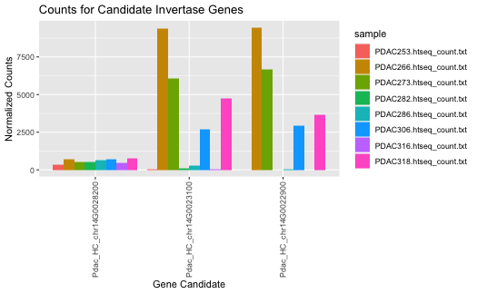

```r
#Make a grouped bar plot with ggplot2 to show count data for candidate genes
ggplot(long, aes(x=variable, y=value, fill=sample)) +
  geom_bar(stat="identity", position=position_dodge())+theme(axis.text.x = element_text(angle = 90, vjust = 0.5, hjust=1))+
  ylab("Normalized Counts")+ xlab("Gene Candidate")+ggtitle("Counts for Candidate Invertase Genes")
```

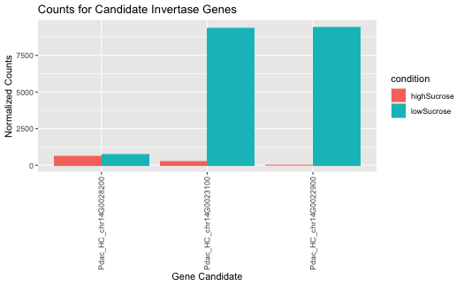

```r
#Make a grouped bar plot with ggplot2 to show count data for candidate genes
ggplot(long, aes(x=variable, y=value, fill=condition)) +
  geom_bar(stat="identity", position=position_dodge())+theme(axis.text.x = element_text(angle = 90, vjust = 0.5, hjust=1))+
  ylab("Normalized Counts")+ xlab("Gene Candidate")+ggtitle("Counts for Candidate Invertase Genes")
```

```r
library(ggplot2)
library(reshape2)
```

DESEq2 log2 fold-change estimates are frequently over-estimated particularly for low expression genes. To obtain better estimates of the log2 fold-change, DESeq2 recommends “shrinking” the raw fold-change estimates DESeq2 makes available the lfcShrink function to extract results from a DESeqDataSet object with shrunken log2 fold-change estimates.

```r
library(devtools)
install_github("stephens999/ashr")
```

```r
res.shrunk <- lfcShrink(dds, contrast = c('condition','lowSucrose','highSucrose'),type='ashr' )
```

```r
res.shrunkOrdered <- res.shrunk[order(res.shrunk$pvalue),]
```

```r
resOrdered
```

[output not shown]

```r
res.shrunkOrdered
```

[output not shown]

### Q3.5 Use the plotMA function to generate MA plots for the res and res.shrunk objects.

It is appropriate to report the shrunken estimates because genes with low expression can have high variability that can be reduced by shrinkage.

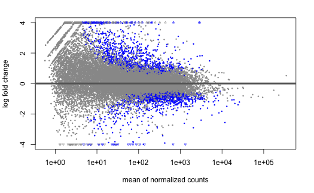

```r
MA1<-plotMA(res, ylim=c(-4,4))
```

```r
MA1
```

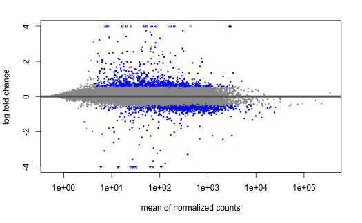

```r
MA2<-plotMA(res.shrunk , ylim=c(-4,4))
```

```r
MA2
```

#Multiple Testing Internally, DESeq2 will perform the False Discovery Rate (FDR) correction by running the p.adjust R core function (?p.adjust) on the raw p-values (pvalue column) using the Benjamin-Hochberg (“BH”) method. The output is reported in the “padj” column and is the adjusted p-value (i.e., the FDR).

### Q4.1 Subset the table with “shrunken” log2 fold-change estimates to include only the candidate genes

### Q4.1a. Report results from the lfcShrink output table for the candidate genes.

```r
subset_res_shrunk<-res.shrunk[candidate_genes,]
subset_res_shrunk
```

```
log2 fold change (MMSE): condition lowSucrose vs highSucrose
Wald test p-value: condition lowSucrose vs highSucrose
DataFrame with 3 rows and 5 columns
                       baseMean log2FoldChange     lfcSE      pvalue        padj
                      <numeric>      <numeric> <numeric>   <numeric>   <numeric>
Pdac_HC_chr14G0022900  2839.320       8.824298  1.168327 1.25031e-16 4.28130e-13
Pdac_HC_chr14G0023100  2915.858       5.372701  0.629431 3.06399e-19 2.62293e-15
Pdac_HC_chr14G0028200   590.073       0.324961  0.217307 8.52678e-02 2.95845e-01
```

```r
logfold_filter<-as.data.frame(subset(res.shrunk, res.shrunk[,2] > 2 |  res.shrunk[,2] < -2))
head(logfold_filter)
```

|  | baseMean | log2FoldChange | lfcSE | pvalue | padj |
| --- | --- | --- | --- | --- | --- |
| Pdac_HC_000007FG0007100 | 14.001465 | -2.410479 | 1.1342918 | 1.899055e-05 | 2.139061e-03 |
| Pdac_HC_000139FG0003500 | 80.248527 | 2.794138 | 0.6547680 | 9.278407e-08 | 3.694317e-05 |
| Pdac_HC_000143FG0007100 | 738.336629 | 2.153099 | 0.5629852 | 4.102711e-08 | 1.756063e-05 |
| Pdac_HC_000160FG0000600 | 10.964668 | -2.626583 | 2.3921995 | 1.313487e-04 | 7.890599e-03 |
| Pdac_HC_000171FG0000200 | 66.376362 | 2.150413 | 0.9658992 | 1.151999e-05 | 1.517183e-03 |
| Pdac_HC_000254FG0005400 | 5.472009 | 2.298655 | 1.9224523 | 1.774722e-04 | 9.646038e-03 |

### Q4.1c Which of the candidate genes do you think could be responsible for the sugar composition trait on the chromosome 14 sugar QTL?

Based on log fold change, Pdac_HC_chr14G0022900 seems to be the best candidate based on the filtered table above. As seen on the bar plot above, it has the biggest ratio expression between low and high sucrose content. This means low sucrose palms express this gene lot whereas high sucrose palms express it minimally.